# Plotting Growth Curves

16 February, 2025

# 1 Introduction

The data that we are going to use for this exercise is published in the mBio paper (Niggli S 2023). It can be found online on: https://doi.org/10.6084/m9.figshare.23578086.v1 It describes the OD600 (growth) of the *Staphylococcus aureus* strain **JE2** in different media.

# 2 Reading in Data and Plotting Growth Curves

```r
dat <- read.table("JE_growth_final.txt", header = TRUE, sep = "\t", stringsAsFactors = TRUE)
# Load tab-separated data from a text file, treating the first row as column headers and converting character columns to factors
```

```
## 'data.frame':    8220 obs. of  6 variables:
##  $ Time                 : num  0 0.5 1 1.5 2 2.5 3 3.5 4 4.5 ...
##  $ OD600_blank_corrected: num  0.00055 0.00055 0.000425 0.00055 0.00065 ...
##  $ Strain               : Factor w/ 1 level "JE2": 1 1 1 1 1 1 1 1 1 1 ...
##  $ Growth_Medium        : Factor w/ 3 levels "NaCl","SN","TSB": 3 3 3 3 3 3 3 3 3 3 ...
##  $ Replicate            : int  1 1 1 1 1 1 1 1 1 1 ...
##  $ Experiment           : Factor w/ 7 levels "exp1","exp2",..: 1 1 1 1 1 1 1 1 1 1 ...
```

```
## [1] 8220    6
```

```
##   Time OD600_blank_corrected Strain Growth_Medium Replicate Experiment
## 1  0.0           0.000549998    JE2           TSB         1       exp1
## 2  0.5           0.000549998    JE2           TSB         1       exp1
## 3  1.0           0.000425001    JE2           TSB         1       exp1
## 4  1.5           0.000549994    JE2           TSB         1       exp1
## 5  2.0           0.000650000    JE2           TSB         1       exp1
## 6  2.5           0.001750000    JE2           TSB         1       exp1
```

```
##      Time OD600_blank_corrected Strain Growth_Medium Replicate Experiment
## 8215 46.0              0.656350    JE2            SN         4       exp7
## 8216 46.5              0.657950    JE2            SN         4       exp7
## 8217 47.0              0.662475    JE2            SN         4       exp7
## 8218 47.5              0.656825    JE2            SN         4       exp7
## 8219 48.0              0.666600    JE2            SN         4       exp7
## 8220 48.5              0.672350    JE2            SN         4       exp7
```

```
## [1] "Time"                  "OD600_blank_corrected" "Strain"
## [4] "Growth_Medium"         "Replicate"             "Experiment"
```

```
##       Time       OD600_blank_corrected Strain     Growth_Medium   Replicate
##  Min.   : 0.00   Min.   :-0.00255      JE2:8220   NaCl:2740     Min.   :1.00
##  1st Qu.:12.00   1st Qu.: 0.52904                 SN  :2740     1st Qu.:1.75
##  Median :24.00   Median : 0.66369                 TSB :2740     Median :2.50
##  Mean   :24.21   Mean   : 0.62075                               Mean   :2.50
##  3rd Qu.:36.50   3rd Qu.: 0.84369                               3rd Qu.:3.25
##  Max.   :48.50   Max.   : 1.24148                               Max.   :4.00
##
##  Experiment
##  exp1:1164
##  exp2:1176
##  exp3:1176
##  exp4:1176
##  exp5:1176
##  exp6:1176
##  exp7:1176
```

```
## [1] 0
```

```
##                  Time OD600_blank_corrected                Strain
##                     0                     0                     0
##         Growth_Medium             Replicate            Experiment
##                     0                     0                     0
```

```
##                  Time OD600_blank_corrected                Strain
##             "numeric"             "numeric"              "factor"
##         Growth_Medium             Replicate            Experiment
##              "factor"             "integer"              "factor"
```

```
## $Time
## NULL
##
## $OD600_blank_corrected
## NULL
##
## $Strain
## [1] "JE2"
##
## $Growth_Medium
## [1] "NaCl" "SN"   "TSB"
##
## $Replicate
## NULL
##
## $Experiment
## [1] "exp1" "exp2" "exp3" "exp4" "exp5" "exp6" "exp7"
```

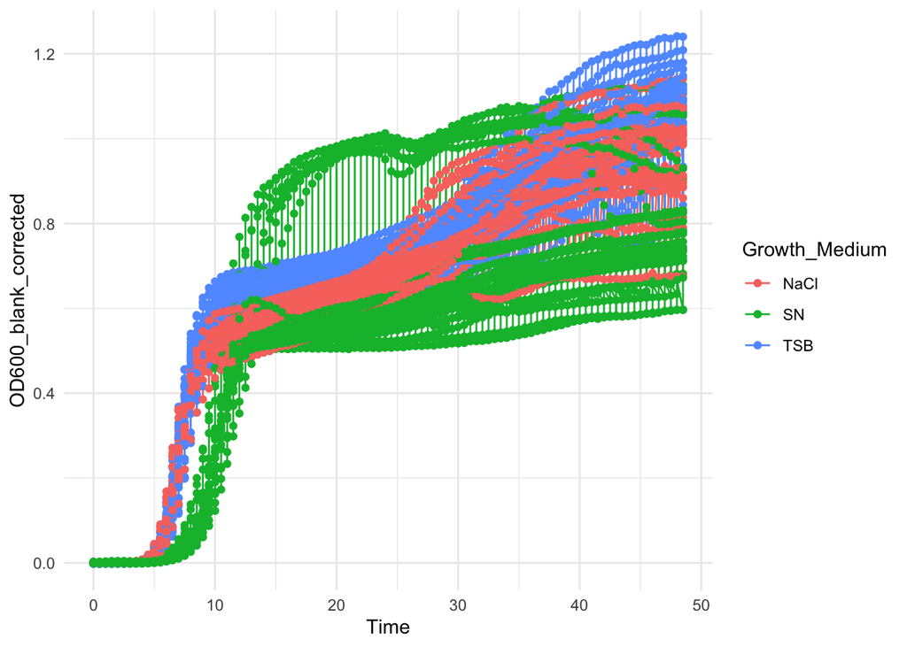

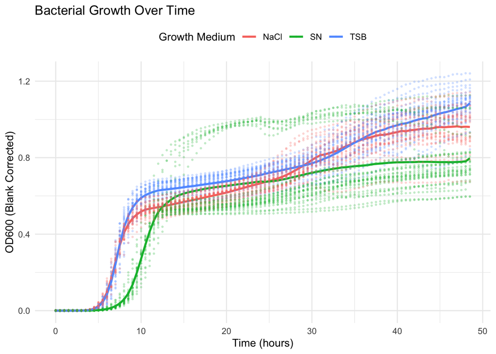

```r
# Visualize growth of bacteria over time for each Growth Medium
dat %>%
  ggplot(aes(x = Time, y = OD600_blank_corrected, color = Growth_Medium)) +  # Define x-axis as Time, y-axis as OD600, and color by Growth_Medium
  geom_line(stat = "summary", fun = mean, linewidth = 1) +  # Plot the mean OD600 value at each time point (summary statistic)
  geom_point(alpha = 0.2, size = 0.5) +  # Add individual data points with transparency (alpha) for clarity
  labs(
    title = "Bacterial Growth Over Time",  # Set plot title
    x = "Time (hours)",                    # Label for the x-axis
    y = "OD600 (Blank Corrected)",         # Label for the y-axis
    color = "Growth Medium"                # Legend label for the Growth Medium
  ) +
  theme_minimal() +  # Use a simple minimal theme for the plot
  theme(legend.position = "top")  # Position the legend at the top of the plot
```

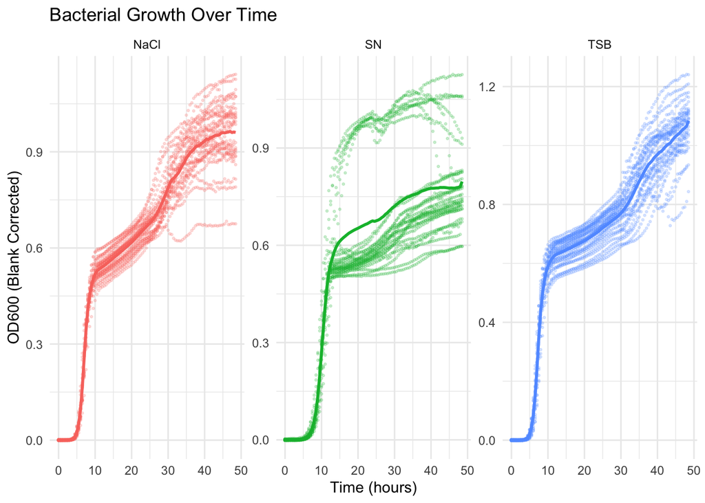

```r
# Visualize growth of bacteria over time for each Growth Medium in separate plots
dat %>%
  ggplot(aes(x = Time, y = OD600_blank_corrected, color = Growth_Medium)) +  # Define x-axis as Time, y-axis as OD600, and color by Growth_Medium
  geom_line(stat = "summary", fun = mean, linewidth = 1) +  # Plot the mean OD600 value at each time point
  geom_point(alpha = 0.2, size = 0.5) +  # Add individual data points with transparency (alpha) for clarity
  labs(
    title = "Bacterial Growth Over Time",
    x = "Time (hours)",
    y = "OD600 (Blank Corrected)",
    color = "Growth Medium"
  ) +
  theme_minimal() +  # Use a simple minimal theme for the plot
  theme(legend.position = "none") +  # Hide the legend (since each plot has a separate color)
  facet_wrap(~ Growth_Medium, scales = "free_y")  # Create separate plots for each Growth Medium with independent y-axis scales
```

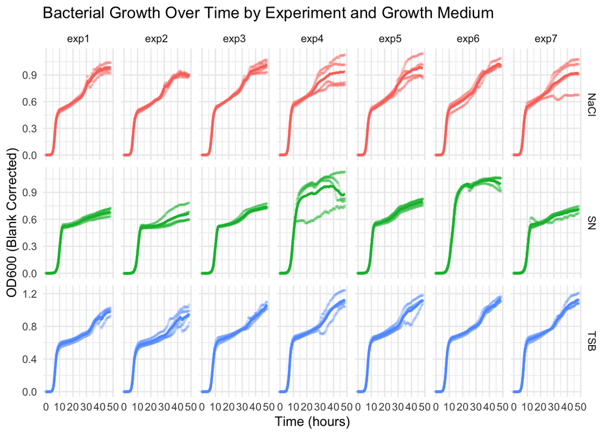

```r
# Visualize growth of bacteria over time for each Growth Medium and Experiment combination in separate plots
dat %>%
  ggplot(aes(x = Time, y = OD600_blank_corrected, color = Growth_Medium)) +  # Define x-axis as Time, y-axis as OD600, and color by Growth_Medium
  geom_line(stat = "summary", fun = mean, linewidth = 1) +  # Plot the mean OD600 value at each time point
  geom_point(alpha = 0.2, size = 0.5) +  # Add individual data points with transparency (alpha) for clarity
  labs(
    title = "Bacterial Growth Over Time by Experiment and Growth Medium",
    x = "Time (hours)",
    y = "OD600 (Blank Corrected)",
    color = "Growth Medium"
  ) +
  theme_minimal() +  # Use a simple minimal theme for the plot
  theme(legend.position = "none") +  # Hide the legend (since each plot has a separate color)
  facet_grid(Growth_Medium ~ Experiment, scales = "free_y")  # Facet by both Growth_Medium and Experiment, with independent y-axis scales
```

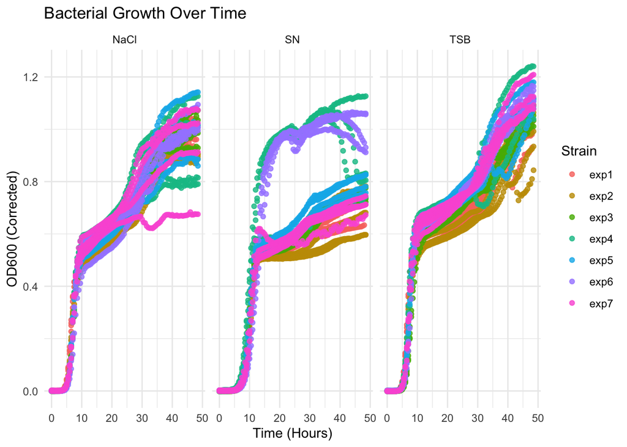

```r
  dat %>%
    ggplot(aes(x = Time, y = OD600_blank_corrected, color = Experiment, linetype = Growth_Medium, group = interaction(Strain, Growth_Medium, Replicate))) +
    geom_point(linewidth = 2, alpha = 0.8) +  # Add points for each measurement
    labs(
      title = "Bacterial Growth Over Time",
      x = "Time (Hours)",
      y = "OD600 (Corrected)",
      color = "Strain",
      linetype = "Growth Medium"
    ) +
    theme_minimal() +
        facet_wrap(~ Growth_Medium) +
    theme(legend.position = "right")
```

```r
# Perform one-way ANOVA to compare OD600 across different Growth Media
anova_results <- dat %>%
  aov(OD600_blank_corrected ~ Growth_Medium, data = .)

# Summarize ANOVA results
summary(anova_results)
```

```
##                 Df Sum Sq Mean Sq F value Pr(>F)
## Growth_Medium    2   19.5   9.746   99.68 <2e-16 ***
## Residuals     8217  803.4   0.098
## ---
## Signif. codes:  0 '***' 0.001 '**' 0.01 '*' 0.05 '.' 0.1 ' ' 1
```

```r
# If ANOVA is significant, perform a post-hoc test (Tukey's HSD)
post_hoc_results <- TukeyHSD(anova_results)

# Display post-hoc results
summary(post_hoc_results)
```

[output not shown]

```
##               Length Class  Mode
## Growth_Medium 12     -none- numeric
```

```r
# Use read.table() for tab-separated files
protein_data <- read.table("qmat_1198.txt", sep = "\t", header = TRUE)

# View the first few rows of the dataset
head(protein_data)
```

```
##   Protein_Gene   sample_1   sample_2   sample_3   sample_4   sample_5
## 1    protein_1 8.4936e+07 2.5415e+07 1.7228e+07   20618000   10659000
## 2    protein_2 1.4061e+10 1.3198e+10 1.2154e+10 6786200000 8886600000
## 3    protein_3 6.1084e+06 6.5811e+05 8.2897e+06    1190400   42510000
## 4    protein_4 0.0000e+00 0.0000e+00 0.0000e+00   17913000   13108000
## 5    protein_5 9.1722e+05 4.4950e+06 5.5513e+05  125290000   73548000
## 6    protein_6 0.0000e+00 3.4399e+06 3.7961e+06    7710300   18011000
##     sample_6
## 1   11718000
## 2 6996300000
## 3     946240
## 4   12714000
## 5  112030000
## 6    9443000
```

```r
# Check the structure of the dataset
str(protein_data)
```

```
## 'data.frame':    1198 obs. of  7 variables:
##  $ Protein_Gene: chr  "protein_1" "protein_2" "protein_3" "protein_4" ...
##  $ sample_1    : num  8.49e+07 1.41e+10 6.11e+06 0.00 9.17e+05 ...
##  $ sample_2    : num  2.54e+07 1.32e+10 6.58e+05 0.00 4.50e+06 ...
##  $ sample_3    : num  1.72e+07 1.22e+10 8.29e+06 0.00 5.55e+05 ...
##  $ sample_4    : num  2.06e+07 6.79e+09 1.19e+06 1.79e+07 1.25e+08 ...
##  $ sample_5    : num  1.07e+07 8.89e+09 4.25e+07 1.31e+07 7.35e+07 ...
##  $ sample_6    : num  1.17e+07 7.00e+09 9.46e+05 1.27e+07 1.12e+08 ...
```

```r
# Reshape the data to long format (Protein_Gene is the identifier, and the samples are columns)
protein_data_long <- protein_data %>%
  pivot_longer(cols = starts_with("sample"),  # Select columns that start with "sample"
               names_to = "Sample",          # New column for sample names
               values_to = "Abundance")     # New column for protein abundance values

# View the reshaped data
head(protein_data_long)
```

```
## # A tibble: 6 × 3
##   Protein_Gene Sample   Abundance
##   <chr>        <chr>        <dbl>
## 1 protein_1    sample_1  84936000
## 2 protein_1    sample_2  25415000
## 3 protein_1    sample_3  17228000
## 4 protein_1    sample_4  20618000
## 5 protein_1    sample_5  10659000
## 6 protein_1    sample_6  11718000
```

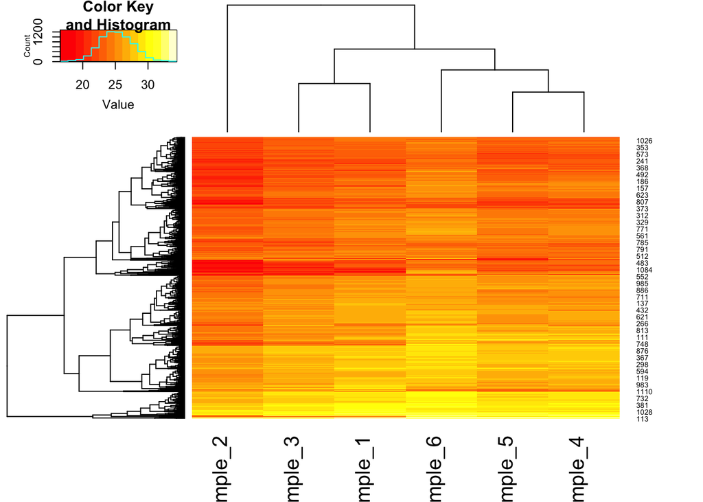

```r
library(gplots)  # Loads the 'gplots' package, which contains the heatmap.2 function
# Convert the data frame to a matrix, excluding the first column (assuming it contains labels)
mat <- as.matrix(protein_data[,2:ncol(protein_data)])

# Replace all zero values in the matrix with NA (to avoid taking log of zero)
mat[mat == 0] <- NA

# Apply log2 transformation to the matrix, removing any NA values before transformation
logmat <- log2(na.omit(mat))

# Generate a heatmap using the transformed matrix, disabling trace lines for clarity
heatmap.2(logmat, trace="none")
```

# 3 Session Information

**R version 4.4.2 (2024-10-31)**

**Platform:** aarch64-apple-darwin20

**locale:** en_US.UTF-8||en_US.UTF-8||en_US.UTF-8||C||en_US.UTF-8||en_US.UTF-8

**attached base packages:** *stats*, *graphics*, *grDevices*, *utils*, *datasets*, *methods* and *base*

**other attached packages:** *gplots(v.3.2.0)*, *lubridate(v.1.9.4)*, *forcats(v.1.0.0)*, *stringr(v.1.5.1)*, *dplyr(v.1.1.4)*, *purrr(v.1.0.4)*, *tidyr(v.1.3.1)*, *tibble(v.3.2.1)*, *ggplot2(v.3.5.1)*, *tidyverse(v.2.0.0)* and *readr(v.2.1.5)*

**loaded via a namespace (and not attached):** *sass(v.0.4.9)*, *utf8(v.1.2.4)*, *generics(v.0.1.3)*, *bitops(v.1.0-9)*, *KernSmooth(v.2.23-24)*, *gtools(v.3.9.5)*, *stringi(v.1.8.4)*, *hms(v.1.1.3)*, *digest(v.0.6.37)*, *magrittr(v.2.0.3)*, *caTools(v.1.18.3)*, *evaluate(v.1.0.3)*, *grid(v.4.4.2)*, *timechange(v.0.3.0)*, *bookdown(v.0.42)*, *fastmap(v.1.2.0)*, *jsonlite(v.1.8.9)*, *pander(v.0.6.5)*, *scales(v.1.3.0)*, *jquerylib(v.0.1.4)*, *cli(v.3.6.3)*, *rlang(v.1.1.5)*, *munsell(v.0.5.1)*, *withr(v.3.0.2)*, *cachem(v.1.1.0)*, *yaml(v.2.3.10)*, *tools(v.4.4.2)*, *tzdb(v.0.4.0)*, *colorspace(v.2.1-1)*, *vctrs(v.0.6.5)*, *R6(v.2.5.1)*, *lifecycle(v.1.0.4)*, *pkgconfig(v.2.0.3)*, *pillar(v.1.10.1)*, *bslib(v.0.9.0)*, *gtable(v.0.3.6)*, *Rcpp(v.1.0.14)*, *glue(v.1.8.0)*, *xfun(v.0.50)*, *tidyselect(v.1.2.1)*, *rstudioapi(v.0.17.1)*, *knitr(v.1.49)*, *farver(v.2.1.2)*, *htmltools(v.0.5.8.1)*, *rmarkdown(v.2.29)*, *labeling(v.0.4.3)* and *compiler(v.4.4.2)*

# References

Niggli S, Poveda L, Schwyter L. 2023. “Rapid and Strain-Specific Resistance Evolution of Staphylococcus Aureus Against Inhibitory Molecules Secreted by Pseudomonas Aeruginosa.” *mBio*. https://doi.org/10.1128/mbio.03153-22.